# Predicting the Injuriousness of Traffic Collisions Occuring in the City of Chicago: A Final Report

Final Project  
Data Science 2 with R (STAT 301-2)

Author

Donny Tou

Published

March 6, 2024

**Github Repo Link**

[Donny’s Final Project Repo](https://github.com/stat301-2-2024-winter/final-project-2-donnytou.git)

## Introduction

In this project, I will investigate the following predictive question: **will any of the unfortunate individuals involved in a traffic collision — both motorists and non-motorists alike — emerge injured?** This is a *classification* problem because it investigates a question of *whether* a traffic incident will be injurious instead of *how many* people are injured.

I want to investigate this predictive problem in particular because of the ubiquity of driving: more than 80 percent of U.S. adults are licensed drivers, with over 90 percent using motor vehicles to transport themselves to-and-from work (Hedges & Company, 2018; Dews, 2013). Driving is relatively cheap and time-efficient, providing individuals with a large amount of geographic freedom and autonomy. Yet, there are **significant costs** to driving: more cars on the road often corresponds to a higher frequency of traffic collisions, many of which can result in debilitating injuries and even death. In fact, the U.S. experiences more motor-vehicle fatalities in both absolute and per-capita terms than any other high-income country (Yellman & Sauber-Schatz, 2022). In attempting to predict the “price tag” of driving (in the form of injurious collisions), I hope to minimize the heavy costs associated with an activity that has become so prevalent in, and important to, daily life.

To build my predictive modelling process, I will be analyzing collision-level crash data covering **traffic incidents occurring within City of Chicago limits and under the jurisdiction of the Chicago Police Department since 2015**[^1]. Approximately half of the observations are self-reported at the police district by the agent(s) involved; the other half are recorded by the responding police officer.

<sup>1</sup> [City of Chicago Traffic Crashes](https://data.cityofchicago.org/Transportation/Traffic-Crashes-Crashes/85ca-t3if/about_data)

## Data Overview

In its raw form, my dataset on Chicago traffic collisions describes over 800,000 crashes with **50 columns** which — after basic cleaning (cleaning column names, factorizing relevant variables, collapsing factor levels) — consist of 27 factor variables, 17 integer variables, 5 string variables, and 1 logical variable. A dataset-wide missingness analysis reveals the following results.

Table 1: Total missingness for each of the 50 variables, summarized

|  | variable | n_miss | pct_miss |
| --- | --- | --- | --- |
| 1 | workers_present_i | 803144 | 100 |
| 2 | dooring_i | 800672 | 99.6922096162083 |
| 3 | work_zone_type | 799553 | 99.55288217305987 |
| 4 | work_zone_i | 798517 | 99.423889115775 |
| 5 | photos_taken_i | 792653 | 98.6937585289811 |
| 6 | statements_taken_i | 785372 | 97.78719631846842 |
| 7 | not_right_of_way_i | 766072 | 95.38414032850896 |
| 8 | crash_date_est_i | 742977 | 92.50856633430618 |
| 9 | intersection_related_i | 619013 | 77.07372525972926 |
| 10 | lane_cnt | 604138 | 75.22162899803772 |

[output cut: 40 more lines]

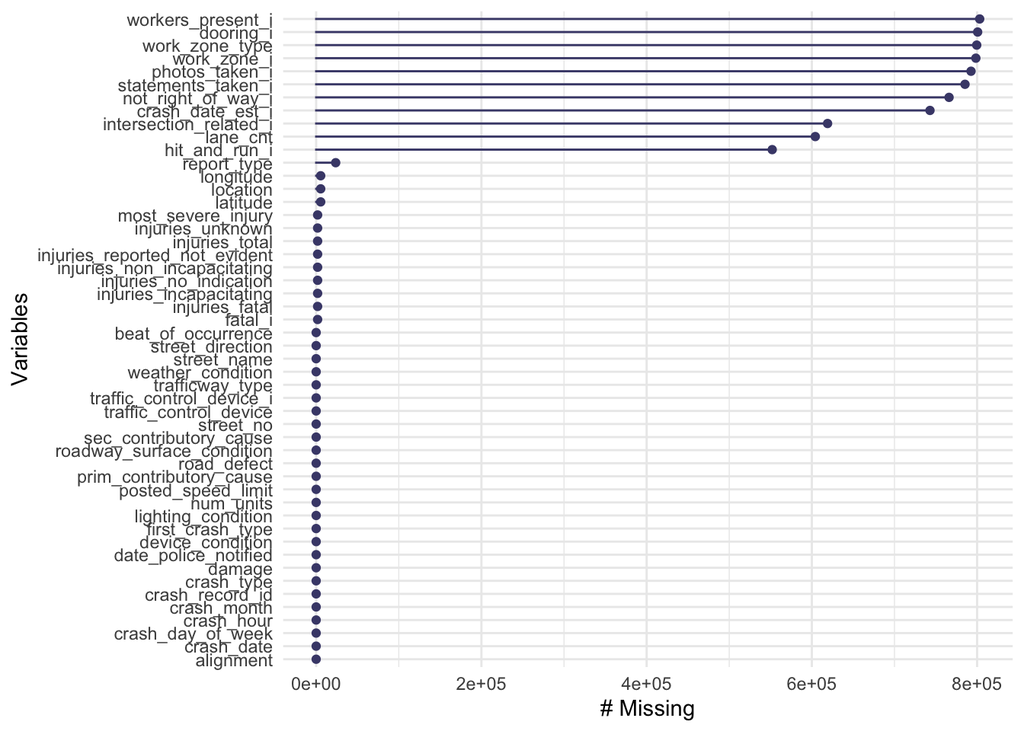

Figure 1: Total missingness for each of the 50 variables, visualized

Table 1 reinforces Figure 1 by showing that 11/50 variables in the data see a missingness rate of over 65%, with the top 8 seeing missing values for over 90% of the entire dataset — a magnitude of missingness that is certainly concerning, especially since it limits my flexibility for feature engineering/selection. Fortunately, the rate of missingness drops precipitously for the remaining 39 variables, which see either zero or close-to-zero missingness.

To construct my **outcome variable of interest**, I condition it using `if_else()` on one of the preexisting variables, `injuries_total`, which is an integer measurement of the *number* of individuals sustaining fatal, incapacitating, non-incapacitating, or possible injuries within a given traffic collision. The resulting binary outcome variable — `injurious` — is appended to the dataset as a new column and is coded as:  
• `Yes` if `injuries_total` exceeds zero;  
• `No` if `injuries_total` equals zero; and  
• `NA` if `injuries_total` is a missing value

I have chosen to take the “classification route” with the new `injurious` variable — as opposed to the “regression route” with existing `injuries_total` variable — so as to preserve the injury-focused nature of my initial question whilst, at the same time, streamline the data downsizing/balancing process (which will be described in the following section).

The following exhibits will explore the missingness and distribution of my `injurious` outcome variable using the original data.

Table 2: Extent of missingness for outcome variable `injurious`

| variable | n_miss | pct_miss |
| --- | --- | --- |
| injurious | 1757 | 0.2187653 |

The outcome variable `injurious` fortunately sees a missingness rate of only 0.22% (Table 2), which means that the process of “throwing out” missing values during recipe building should not generate significant disruptions/bias. Next, I will explore the distribution of `injurious` across the raw dataset after excluding the 1,757 (out of 803,144) observations that lack data on injuriousness.

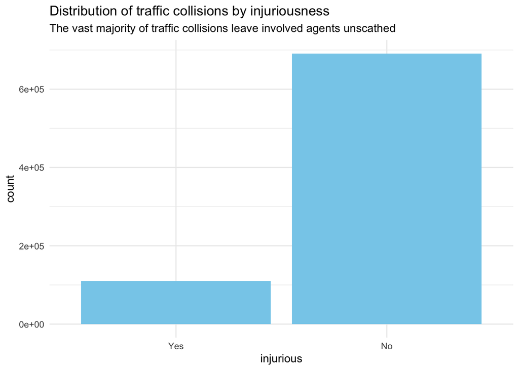

Figure 2: Distribution of `injurious`, visualized

Table 3: Distribution of `injurious`, summarized

| injurious | n |
| --- | --- |
| Yes | 110241 |
| No | 691146 |

Figure 2 and Table 3 reveal a large amount of class imbalance in `injurious`: non-injurious collisions significantly outnumber injurious collisions, with the ratio between the two classes exceeding 6:1. This warrants **2 additional steps** that will be taken — dataset downsizing and stratified random sampling — which will be described in further detail in the next section.

Specifically, this next section will explore in detail my steps of data splitting, model building/tuning, and recipe engineering.

## Methods

### Dataset Downsampling/Downsizing

Prior to spending my dataset, I first run it through **2 prerequisite steps**: *downsampling* and *downsizing*. The sheer size of my dataset in its raw form (with 800,000+ rows) is unsustainable given my computational and temporal constraints; additionally, the class imbalance existing within my binomial outcome variable, `injurious`, warrants adjustments. I address both of these concerns in tandem through these 2 steps:

1. **Downsampling**: After throwing out missing data (~0.22% of rows), I use `slice_sample()` to randomly downsample my dataset with respect to the underrepresented class in `injurious`, “Yes”. This reduces the number of observations from over 800,000 to about 220,000[^2] and at the same time ensures a 1:1 class balance in my dummy outcome variable.
2. **Additional downsizing**: A 220,000-row dataset still exceeds my computational limits; as such, I further downsize my sample via random selection using `initial_split()`. The result is a ~44,000-row final dataset, exactly 20% as large as post-downsampling dataset and roughly 5-6% as large as the original dataset.

<sup>2</sup> The number of observations in the underrepresented outcome variable class — collisions that *are* injurious — is about 110,000 in the raw dataset

### Data Splitting

Next, I use an *80:20 proportion* combined with *stratified random sampling* (with respect to `injurious`) in `initial_split()` in order to split this final dataset into **training** and **testing** sets. Within the training set of roughly 35,000 rows, I then use **V-fold cross-validation** to generate resampled data on which I later conduct my model competition process. Specifically, my resampling process entails randomly partioning my training set into 5 subsets (`v` = 5) repeated 3 times (`repeats` = 3), generating **15 resamples/folds** — each of which contains roughly 7,000 observations[^3] — on which my various models are trained and evaluated.

<sup>3</sup> Within each 7,000-row fold, 80% of rows are allocated to training and the remaining 20% are allocated to testing since `v` = 5

```
<Training/Testing/Total>
<35276/8820/44096>
```

Table 4: Data set observation count post-splitting

# of training set rows post-split

| n |
| --- |
| 35276 |

# of testing set rows post-split

| n |
| --- |
| 8820 |

The series of visuals in Table 4 reveal that the 80:20-proportion split has been successfully implemented.

### Model Building/Tuning

I define and, using a regular grid, tune the **7 following models**[^4] — the first 2 being *baseline* models — for use in my model competition:

<sup>4</sup> To accomodate the binomial nature of `injurious`, all 7 models use `mode` = “classification”

1. **Null**: A simple baseline null model defined using `null_model()` with the `parsnip` engine.
2. **Naive Bayes**: A simple “step-up” baseline model defined using `naive_Bayes()` with the `klaR` engine.
3. **Logistic regression**: A *parametric* non-regularized regression model defined using `logistic_reg()` with the `glm` engine.
4. **Elastic net**: A *parametric* regularized regression model defined using `logistic_reg()` with the `glmnet` engine and the following tuning parameters:
   1. Mixture explored over [0, 1] with 10 levels
   2. Penalty explored over [-3, 0] with 10 levels
5. **K-nearest neighbors**: A *non-parametric* algorithm defined using `nearest_neighbor()` with the `kknn` engine and the following tuning parameter:
   1. Neighbors explored over [1, 15] with 5 levels
6. **Random forest**: A *non-parametric*, independently-trained algorithm defined using `rand_forest()` with the `ranger` engine, 500 `trees`, and the following tuning parameters:
   1. Number of predictors randomly sampled at each split explored over [1, 5] with 4 levels
   2. Minimum number of node data points required for further splitting explored over [2, 40] with 4 levels
7. **Boosted tree**: A *non-parametric*, sequentially-trained algorithm defined using `boost_tree()` with the `xgboost` engine, 500 trees, and the following tuning parameters:
   1. Number of predictors randomly sampled at each split explored over [1, 5] with 4 levels
   2. Minimum number of node data points required for further splitting explored over [2, 40] with 4 levels
   3. Learning rate explored over [-5, -0.2] on log-10 scale with 4 levels

### Recipe Engineering

Next, the recipes I use in conjuction with my 7 models are constructed along *2 independent dimensions*:

1. **“Kitchen sink” .vs. “feature engineered”**: These differ on the basis of feature selection; my *kitchen sink* recipe uses as many predictors as possible, while my *feature engineered* recipe is more selective with the predictors used
   1. The kitchen sink feature selection only *filters out* 26 “unacceptable” predictors[^5] which are variables that:
      1. See missingness rates in excess of 90% (e.g. `workers_present_i`);
      2. Are too closely correlated with `injurious` (e.g. `injuries_total`);
      3. Contain too many factor levels, often because they serve as identifiers (e.g. `crash_record_id`)
   2. The feature engineered selection, on the other hand, *actively includes* 11 predictors[^6] — `alignment`, `posted_speed_limit`, `lane_cnt`, `intersection_related_i`, `trafficway_type`, `device_condition`, `report_type`, `first_crash_type`, `num_units`, `lighting_condition`, and `month` — which I select on the basis of having observable/notable bivariate relationships with `injurious`[^7]
2. **Parametric .vs. non-parametric**: Recipes that are compatible with my *3 parametric models* (null, logistic regression, and elastic net) differ from recipes meant for my *3 non-parametric models* (nearest neighbors, random forest, and boosted tree) in 2 ways…
   1. Unlike their parametric counterparts, my non-parametric recipes use *one-hot encoding* when converting factor variables into numeric terms
   2. Unlike their non-parametric counterparts, my parametric recipes incorporate *interaction terms* between 5 predictors[^8]: `lighting_condition`, `num_units`, `trafficway_type_`, `intersection_related_i`, and `alignment`

<sup>6</sup> refer to `README.md` within the `data/` subdirectory for variable definitions

<sup>8</sup> This comparison only applies for the *feature engineered* parametric/non-parametric recipes; the *kitchen sink* recipe is intentionally kept simple in its omission of interaction terms

These 2 dimensions alone generate *4 possible recipe combinations*: parametric + kitchen sink, parametric + feature engineered, non-parametric + kitchen sink, and non-parametric + feature engineered. In addition to their differences, all models share the **same basic pre-processing steps** of **a)** imputing missing predictor values using nearest neighbors; **b)** dummy-encoding all factor predictors; **c)** removing predictor variables with zero variance; and **d)** centering/scaling all numeric predictors.

Importantly, I include an additional recipe designed *exclusively* for the naive Bayes model; this recipe is identical to the parametric + kitchen sink model, except it omits the pre-processing step of dummy-encoding factor variables. I therefore end up with **5 total recipes**: the 4 combinations detailed above and the naive-Bayes-specific specification.

### Assessment Metric

So that I can systematically compare the predictive performances of my various models and their recipe specifications, I will use the **`accuracy` assessment metric** — which measures the proportion of observations guessed correctly by a given model — for its easy interpretability as well as its compatibility with the binomial nature of my `injurious` outcome variable.

## Model Building & Selection Results

### Model Candidates

In the ensuing model competition process, my 2 baseline models (null and naive Bayes) are individually matched with 1 recipe[^9], while the other 5 more-complex models are each individually matched with 2 recipes. The **recipe-by-recipe breakdown** is as follows:

<sup>9</sup> The naive Bayes model uses its designated recipe specification while the null model uses the parametric + kitchen sink recipe specification

1. *Naive Bayes recipe only*: matched only to the naive Bayes model;
2. *Parametric + kitchen sink recipe only:* matched only to the null model;
3. *Parametric + kitchen sink recipe AND parametric + feature engineered recipe*: matched to the logistic regression and elastic net models;
4. *Non-parametric + kitchen sink recipe AND non-parametric + feature engineered recipe*: matched to the nearest neighbors, random forest, and boosted tree models

### Fitted Results: General Takeaways

The following exhibit displays the `accuracy` results of the best-performing candidates for each model/recipe combination[^10], fitted and then averaged across the 15 resamples/folds:

<sup>10</sup> For context, complex models that are fit using *kitchen sink* recipes are denoted with “1”, and complex models that are fit using *feature engineered* recipes are denoted with “2”

Table 5: Model competition results using the `accuracy` metric

|  | model | .metric | .estimator | mean | std_err | n |
| --- | --- | --- | --- | --- | --- | --- |
| 1 | null | accuracy | binary | 0.5 | 0 | 15 |
| 2 | nbayes | accuracy | binary | 0.6547239993562243 | 0.006202290849922765 | 15 |
| 3 | logistic1 | accuracy | binary | 0.7651378036959673 | 0.001213480078963934 | 15 |
| 4 | logistic2 | accuracy | binary | 0.6981257986923466 | 0.02347385737810442 | 15 |
| 5 | en1 | accuracy | binary | 0.7649393829610728 | 0.001235211322603731 | 15 |
| 6 | en2 | accuracy | binary | 0.7509449214900022 | 0.001217699145863033 | 15 |
| 7 | knn1 | accuracy | binary | 0.7118248498088711 | 0.00081884129543602 | 15 |
| 8 | knn2 | accuracy | binary | 0.6847997233735822 | 0.001269665444303865 | 15 |
| 9 | rf1 | accuracy | binary | 0.7656480131352544 | 0.00109351229513352 | 15 |
| 10 | rf2 | accuracy | binary | 0.7522867540993022 | 0.001116191458219488 | 15 |

[output cut: 2 more lines]

Below is the same table, but rearranged such that the best-performing models are at the top:

Table 6: Model competition results using the `accuracy` metric, arranged in descending order

|  | model | .metric | .estimator | mean | std_err | n |
| --- | --- | --- | --- | --- | --- | --- |
| 1 | boosted1 | accuracy | binary | 0.7659976402746462 | 0.001030831058088122 | 15 |
| 2 | rf1 | accuracy | binary | 0.7656480131352544 | 0.00109351229513352 | 15 |
| 3 | logistic1 | accuracy | binary | 0.7651378036959673 | 0.001213480078963934 | 15 |
| 4 | en1 | accuracy | binary | 0.7649393829610728 | 0.001235211322603731 | 15 |
| 5 | rf2 | accuracy | binary | 0.7522867540993022 | 0.001116191458219488 | 15 |
| 6 | boosted2 | accuracy | binary | 0.7520694851358305 | 0.001117169950278248 | 15 |
| 7 | en2 | accuracy | binary | 0.7509449214900022 | 0.001217699145863033 | 15 |
| 8 | knn1 | accuracy | binary | 0.7118248498088711 | 0.00081884129543602 | 15 |
| 9 | logistic2 | accuracy | binary | 0.6981257986923466 | 0.02347385737810442 | 15 |
| 10 | knn2 | accuracy | binary | 0.6847997233735822 | 0.001269665444303865 | 15 |

[output cut: 2 more lines]

There are **3 general takeaways** from Table 5 and Table 6:

1. The **top-performing individual model** per the `accuracy` metric is the *boosted tree model fit using the kitchen sink recipe*;
2. Across all complex model types, the **kitchen sink recipe strictly dominates the feature engineered recipe** when it comes to predictive accuracy;
   1. This suggests that, in my case, feature engineering is **not worth it**: it adds additional effort and yields worse results
   2. This **does not** necessarily suggest, however, that a kitchen sink strategy for feature selection is in general strictly superior to a more selective one
      1. In my case, it is likely that I may have simply omitted key variables that I *should* have included in the construction of my feature engineered recipe
3. Among the top-performing complex models, there appear to be **close-to-zero differences** in predictive performance
   1. For instance, the difference in mean `accuracy` between my top performer (`boosted1`) and the “runner-up” (`rf1`) is only 0.0003496, which is merely a 0.0457% difference in performance
   2. Nonetheless, the 5 non-baseline models do appear to perform with greater predictive accuracy than the baseline `null` and `nbayes` models at a non-insignificant level

### The Top-Performing Model Candidate

More specifically, the top-performing model (`boosted1`) on average correctly predicts the injury status of approximately 76.60% of collisions across the 15 resamples/folds. Note, however, that this winning candidate represents only *1 of the 64* boosted tree models created via tuning combinations during the model-building process. Therefore, the following exhibits explore in further detail the particular **tuning parameters** of the the winning `boosted1` model:

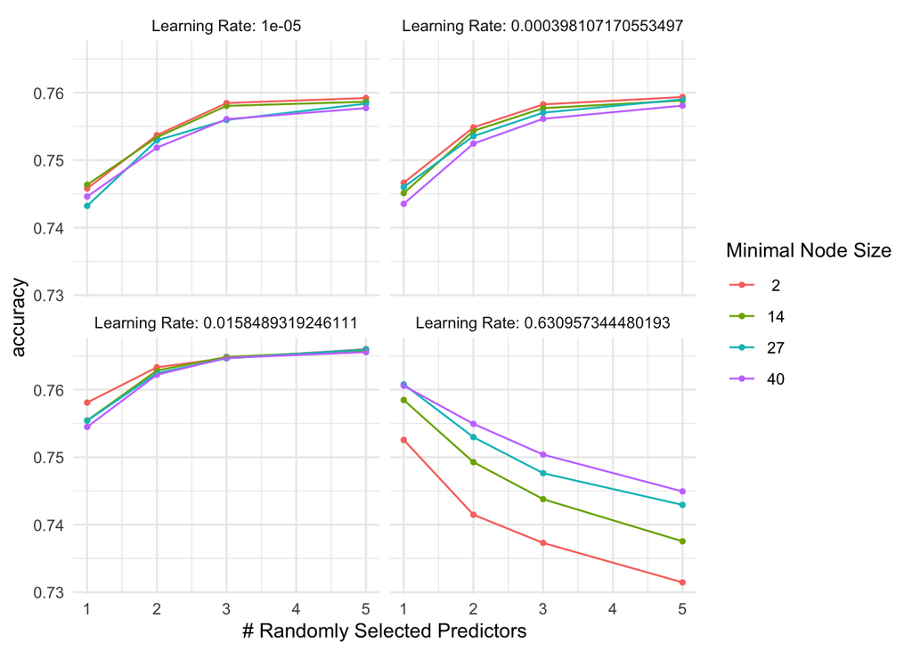

Figure 3: A visual inspection of tuning parameter performances for the boosted tree model class

The endline result from Figure 3 regarding our singular best-performing boosted tree model can be summarized in the following table:

Table 7: Exact hyperparameter values for the top-performing model, `boosted1`

| mtry | min_n | learn_rate | .config |
| --- | --- | --- | --- |
| 5 | 2 | 0.0158489 | Preprocessor1_Model36 |

The following statement can be drawn from Table 7: *conditional on having a `learn_rate` equaling -1.8 (log-scaled), my boosted tree model performs with the greatest predictive accuracy using the smallest possible `min_n` and largest possible `mtry` values of 2 and 5 respectively*. The most puzzling conclusion from this tuning analysis is that there is no clear-cut answer regarding the optimal `learn_rate`; it does not seem to follow a predictable “ceteris-paribus” pattern with respect to `accuracy`, which is particularly concerning because the value of `learn_rate` appears to also determine the optimal hyperparameter values for `min_n` and `mtry` as well. As such, a case can be made that **further tuning should be explored** with respect to the `learn_rate` parameter; perhaps a more optimal value exists and can potentially be uncovered via, for example, an exploration conducted across more levels.

### Additional Tuning Analysis: Other Candidates

The following exhibit explores the optimal tuning parameter values for the best-performing representatives of the **3 other model types** marked for tuning: random forest, K-nearest neighbors, and elastic net.

|  | model | penalty | mixture | neighbors | mtry | min_n |
| --- | --- | --- | --- | --- | --- | --- |
| 1 | en1 | 0.001 | 0.1111111111111111 |  |  |  |
| 2 | en2 | 0.002154434690031884 | 0.1111111111111111 |  |  |  |
| 3 | knn1 |  |  | 15 |  |  |
| 4 | knn2 |  |  | 15 |  |  |
| 5 | rf1 |  |  |  | 5 | 27 |
| 6 | rf2 |  |  |  | 5 | 27 |

Table 8 reveals that the optimal tuning hyperparameters for each model are generally consistent across the kitchen sink and feature engineered recipes; the only exception to this is the elastic net model, whose optimal hyperparameter value for `penalty` slightly differs between the two. As for the remaining 2 models:

1. *K-nearest neighbors model*: Its predictive performance is optimized with the largest possible number of `neighbors` (15)
2. *Random forest model*: Its predictive performance is optimized with the largest `mtry` value (5) and a moderate number of `min_n` (27)

### Building More Complex Models: Is It Worth It?

Perhaps one of the most important queries to investigate in the context of model competition/selection is **whether it is truly worth it** to build more complex models which, in my case, are the logistic regression, elastic net, K-nearest neighbors, random forest, and boosted tree models. Given my results from Table 6, I draw the following **2 conclusions**:

1. At a fundamental level, it appears to be **certainly worth it** to build more complex models beyond the baselines
   1. Relative to the *null* baseline model, the top 7 competitors see accuracy rates at least 25 percentage points (or 50%) higher
   2. Relative to the *naive Bayes* baseline model, the same top 7 competitors see accuracy rates around 10-11 percentage points (or 15-17%) higher
2. There is, however, a catch: *conditional on having more-complex models*, it **does not appear to be worth it** to introduce even more complexity
   1. For instance, `boosted2` performs only slightly better than `en2` using the same underlying recipe

## Final Model Analysis

Finally, I apply the resulting fitted model to my testing set of ~9,000 rows — all in order to see how this winning model performs on **never-before-seen-data**. The following exhibits display my results.

Table 9: Tibble of predicted class probabilities and actual/true outcomes

|  | injurious | .pred_class | .pred_Yes | .pred_No |
| --- | --- | --- | --- | --- |
| 1 | No | No | 0.0886688232421875 | 0.9113311767578125 |
| 2 | No | No | 0.2607690393924713 | 0.7392309606075287 |
| 3 | No | No | 0.4089017808437347 | 0.5910982191562653 |
| 4 | No | Yes | 0.6168985366821289 | 0.3831014633178711 |
| 5 | No | No | 0.2961796224117279 | 0.7038203775882721 |
| 6 | No | No | 0.1178429126739502 | 0.8821570873260498 |
| 7 | No | No | 0.2274975478649139 | 0.7725024521350861 |
| 8 | No | No | 0.4174169898033142 | 0.5825830101966858 |
| 9 | No | No | 0.05387628823518753 | 0.9461237117648125 |
| 10 | No | No | 0.2262954115867615 | 0.7737045884132385 |

[output cut: 8810 more lines]

Table 9 provides a side-by-side comparison between the actual and predicted `injurious` values of the 8,820 traffic collisions within my testing set, as well as the class probabilities assigned to each of the 2 levels — `Yes` and `No` — per collision.

Table 10: Performance summary of `boosted1` on testing data using `accuracy`

| .metric | .estimator | .estimate |
| --- | --- | --- |
| accuracy | binary | 0.764966 |

Using the `accuracy` metric, Table 10 reveals that the winning boosted tree model correctly predicts the injury status of a given collision **76.497%** of the time within the testing set.

Now, let’s further decompose this predictive assessment using a **confusion matrix**.

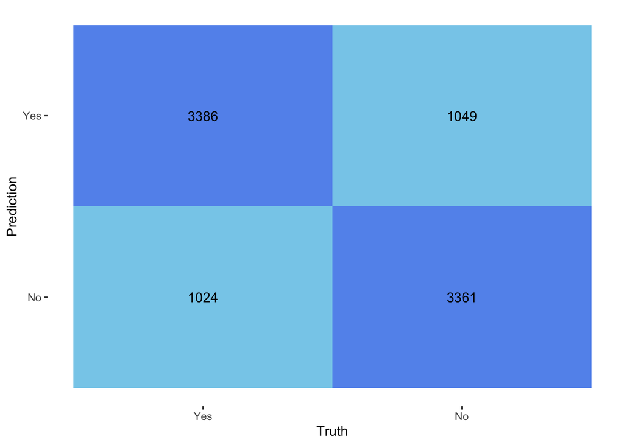

Figure 4: A 2x2 confusion matrix comparing predicted .vs. actual `injurious` class values.

1. 3,386 predictions are **true positives** — injurious collisions that are correctly predicted to be injurious by the model
2. 3,361 predictions are **true negatives** — non-injurious collisions that are correctly predicted to be non-injurious by the model
3. 1,049 predictions are **false positives** — collisions that are predicted to be injurious but are actually non-injurious
4. 1,024 predictions are **false negatives** — collisions that are predicted to be non-injurious but are actually injurious

Overall, a **final accuracy metric of 76.497%** on the assessment data is a slight decline from 76.60% — the final model’s accuracy metric on the *resampled* data — which is a 0.103-percentage-point decrease. This is to be expected, since `boosted1`, which was trained across the resampled training folds, is now fit on “never-before-seen” data.

Overall, I believe that this is a **solid performance**: even on never-before-seen data, this final model’s accuracy metric is **a)** over 25 percentage points (50%) more accurate than the null model and **b)** over 11 percentage points (17%) more accurate than the naive Bayes model, both of which are assessed across the 15 resamples. While this is not a magnificent performance, I believe it **does justify** building more complex models beyond just the baselines.

Still, this model is **far from perfect**; analyses from previous reports identify **3 key caveats** to the efficacy of this final model:

1. The underlying kitchen sink recipe matched with this recipe is not necessarily optimal
   1. Its superior performance against my feature engineered recipe may point towards a flaw in my feature engineering — not necessarily the dominance of a kitchen sink selection strategy
2. The “objectively optimal” hyperparameter values for `min_n`, `mtry`, and `learn_rate` are still not exactly known
   1. This analysis merely identified the best-performing tuning set among 64 possible boosted-tree-model combinations, but more combinations exist and should be explored if computational constraints allow for it
3. Although `boosted1` is the top performer among candidates in Table 6, the differences across the upper 50% of candidates are marginal at-best
   1. If this model is “any good”, then it is likely that the runner-ups are as well to very similar degrees

## References

*How many licensed drivers are there in the US?* (2018). Hedges & Company. [https://hedgescompany.com/blog/2018/10/number-of-licensed-drivers-usa/#:~:text=Across%20all%20age%20groups%2C%2084.1,population%20has%20a%20driver’s%20license](https://hedgescompany.com/blog/2018/10/number-of-licensed-drivers-usa/#:~:text=Across%20all%20age%20groups%2C%2084.1,population%20has%20a%20driver's%20license)

Yellman, M. A. & Sauber-Schatz, E. K. (2022). Motor Vehicle Crash Deaths — United States and 28 Other High-Income Countries, 2015 and 2019. *Morbidity and Mortality Weekly Report (MMWR)*, 71(26), 837-843. https://www.cdc.gov/mmwr/volumes/71/wr/mm7126a1.htm?s_cid=mm7126a1_w#suggestedcitation

## Appendix: EDA

Recall that the feature selection/engineering steps *unique to this recipe* consist of the following components:

1. **11 predictors/“features”** [^11]: `alignment`, `posted_speed_limit`, `lane_cnt`, `intersection_related_i`, `trafficway_type`, `device_condition`, `report_type`, `first_crash_type`, `num_units`, `lighting_condition`, and `month`
2. **4 interaction terms** created using 5 features — `lighting_condition`, `num_units`, `trafficway_type_`, `intersection_related_i`, and `alignment` — and defined as the following…
   1. An interaction term between `num_units` and `lighting_condition`
   2. An interaction term between `num_units` and `trafficway_type`
   3. An interaction term between `alignment` and `lighting_condition`
   4. An interaction term between `alignment` and `intersection_related_i`

<sup>11</sup> refer to `README.md` within the `data/` subdirectory for variable definitions

## Appendix: Technical Info